# Introduction

Google Trends gives us an estimate of search volume. Let's explore if search popularity relates to other kinds of data. Perhaps there are patterns in Google's search volume and the price of Bitcoin or a hot stock like Tesla. Perhaps search volume for the term "Unemployment Benefits" can tell us something about the actual unemployment rate?

Data Sources:

- [Unemployment Rate from FRED](https://fred.stlouisfed.org/series/UNRATE/)
- [Google Trends](https://trends.google.com/trends/explore)
- [Yahoo Finance for Tesla Stock Price](https://finance.yahoo.com/quote/TSLA/history?p=TSLA)
- [Yahoo Finance for Bitcoin Stock Price](https://finance.yahoo.com/quote/BTC-USD/history?p=BTC-USD)

# Import Statements

```python
import pandas as pd
import matplotlib.pyplot as plt
```

# Read the Data

Download and add the .csv files to the same folder as your notebook.

```python
df_tesla = pd.read_csv('TESLA Search Trend vs Price.csv')

df_btc_search = pd.read_csv('Bitcoin Search Trend.csv')
df_btc_price = pd.read_csv('Daily Bitcoin Price.csv')

df_unemployment = pd.read_csv('UE Benefits Search vs UE Rate 2004-19.csv')
```

# Data Exploration

### Tesla

**Challenge**:

- What are the shapes of the dataframes?
- How many rows and columns?
- What are the column names?
- Complete the f-string to show the largest/smallest number in the search data column
- Try the `.describe()` function to see some useful descriptive statistics
- What is the periodicity of the time series data (daily, weekly, monthly)?
- What does a value of 100 in the Google Trend search popularity actually mean?

```python
df_tesla.head()
```

|  | MONTH | TSLA_WEB_SEARCH | TSLA_USD_CLOSE |
| --- | --- | --- | --- |
| 0 | 2010-06-01 | 3 | 4.766 |
| 1 | 2010-07-01 | 3 | 3.988 |
| 2 | 2010-08-01 | 2 | 3.896 |
| 3 | 2010-09-01 | 2 | 4.082 |
| 4 | 2010-10-01 | 2 | 4.368 |

```python
df_tesla.shape
```

```
(124, 3)
```

```python
print(f'Largest value for Tesla in Web Search: {df_tesla.TSLA_WEB_SEARCH.max()}')
print(f'Smallest value for Tesla in Web Search: {df_tesla.TSLA_WEB_SEARCH.min()}')
```

```
Largest value for Tesla in Web Search: 31
Smallest value for Tesla in Web Search: 2
```

### Unemployment Data

```python
df_unemployment.head(3)
```

|  | MONTH | UE_BENEFITS_WEB_SEARCH | UNRATE |
| --- | --- | --- | --- |
| 0 | 2004-01 | 34 | 5.7 |
| 1 | 2004-02 | 33 | 5.6 |
| 2 | 2004-03 | 25 | 5.8 |

```python
df_unemployment.shape
```

```
(181, 3)
```

```python
print('Largest value for "Unemployemnt Benefits" '
      f'in Web Search: {df_unemployment.UE_BENEFITS_WEB_SEARCH.max()}')
```

```
Largest value for "Unemployemnt Benefits" in Web Search: 100
```

### Bitcoin

```python
df_btc_search.head(3)
```

|  | MONTH | BTC_NEWS_SEARCH |
| --- | --- | --- |
| 0 | 2014-09 | 5 |
| 1 | 2014-10 | 4 |
| 2 | 2014-11 | 4 |

```python
df_btc_search.shape
```

```
(73, 2)
```

```python
df_btc_price.head(3)
```

|  | DATE | CLOSE | VOLUME |
| --- | --- | --- | --- |
| 0 | 2014-09-17 | 457.334015 | 21056800.0 |
| 1 | 2014-09-18 | 424.440002 | 34483200.0 |
| 2 | 2014-09-19 | 394.795990 | 37919700.0 |

```python
df_btc_price.shape
```

```
(2204, 3)
```

```python
print(f'largest BTC News Search: {df_btc_search.BTC_NEWS_SEARCH.max()}')
```

```
largest BTC News Search: 100
```

### Using `.describe()` function

```python
df_tesla.describe()
```

|  | TSLA_WEB_SEARCH | TSLA_USD_CLOSE |
| --- | --- | --- |
| count | 124.000000 | 124.000000 |
| mean | 8.725806 | 50.962145 |
| std | 5.870332 | 65.908389 |
| min | 2.000000 | 3.896000 |
| 25% | 3.750000 | 7.352500 |
| 50% | 8.000000 | 44.653000 |
| 75% | 12.000000 | 58.991999 |
| max | 31.000000 | 498.320007 |

### What do the Search Numbers mean?

We can see from our DataFrames that Google's search interest ranges between 0 and 100. But what does that mean? Google defines the values of search interest as:

> Numbers represent search interest relative to the highest point on the chart for the given region and time. A **value of 100 is the peak popularity** for the term. A **value of 50 means that the term is half as popular**. A score of 0 means there was not enough data for this term.

Basically, the actual search volume of a term is not publicly available. Google only offers a scaled number. Each data point is divided by the total searches of the geography and time range it represents to compare relative popularity.

For each word in your search, Google finds how much search volume in each region and time period your term had relative to all the searches in that region and time period. It then combines all of these measures into a single measure of popularity, and then it scales the values across your topics, so the largest measure is set to 100. In short: Google Trends doesn’t exactly tell you how many searches occurred for your topic, but it does give you a nice proxy.

Here are the [Google Trends](https://trends.google.com) Search Parameters that I used to generate the .csv data:

- "Tesla", Worldwide, Web Search
- "Bitcoin", Worldwide, News Search
- "Unemployment Benefits", United States, Web Search

[figure not shown]

# Data Cleaning

### Check for Missing Values

**Challenge**: Are there any missing values in any of the dataframes? If so, which row/rows have missing values? How many missing values are there?

```python
print(f'Missing values for Tesla?: {df_tesla.isna().any().any()}')
print(f'Missing values for U/E?: {df_unemployment.isna().any().any()}')
print(f'Missing values for BTC Search?: {df_btc_search.isna().any().any()}')
```

```
Missing values for Tesla?: False
Missing values for U/E?: False
Missing values for BTC Search?: False
```

We could also use:

`df_tesla.isna().values.any()`

```python
print(f'Missing values for BTC price?: {df_btc_price.isna().values.any()}')
```

```
Missing values for BTC price?: True
```

It is possible to sum boolean values:

```python
a = True
b = True
a + b
```

```
2
```

```python
df_btc_price.isna().values
```

```
array([[False, False, False],
       [False, False, False],
       [False, False, False],
       ...,
       [False, False, False],
       [False, False, False],
       [False, False, False]])
```

```python
bool([False,False,False])  # True because list not empty, only empty list is falsey
```

```
True
```

```python
bool(df_btc_price.isna().values)
```

```
---------------------------------------------------------------------------
ValueError                                Traceback (most recent call last)
<ipython-input-20-4461fa50ed7f> in <module>
----> 1 bool(df_btc_price.isna().values)

ValueError: The truth value of an array with more than one element is ambiguous. Use a.any() or a.all()
```

```python
print(f'Number of missing values: {df_btc_price.isna().values.sum()}')  # using the sum
```

```
Number of missing values: 2
```

**Challenge**: Remove any missing values that you found.

```python
df_btc_price.loc[df_btc_price.CLOSE.isna() | df_btc_price.DATE.isna() | df_btc_price.VOLUME.isna()]
```

|  | DATE | CLOSE | VOLUME |
| --- | --- | --- | --- |
| 2148 | 2020-08-04 | NaN | NaN |

```python
df_btc_price[2146:2151]
```

|  | DATE | CLOSE | VOLUME |
| --- | --- | --- | --- |
| 2146 | 2020-08-02 | 11053.614258 | 2.741007e+10 |
| 2147 | 2020-08-03 | 11246.348633 | 2.027171e+10 |
| 2148 | 2020-08-04 | NaN | NaN |
| 2149 | 2020-08-05 | 11747.022461 | 2.441125e+10 |
| 2150 | 2020-08-06 | 11779.773438 | 2.340074e+10 |

To remove a missing value we can use .dropna(). The inplace argument allows to overwrite our DataFrame.

```python
df_btc_price = df_btc_price.dropna()
```

### Convert Strings to DateTime Objects

**Challenge**: Check the data type of the entries in the DataFrame MONTH or DATE columns. Convert any strings in to Datetime objects. Do this for all 4 DataFrames. Double check if your type conversion was successful.

```python
print(type(df_btc_price.DATE[1]))
print(type(df_btc_search.MONTH[1]))
print(type(df_tesla.MONTH[1]))
print(type(df_unemployment.MONTH[1]))
```

```
<class 'str'>
<class 'str'>
<class 'str'>
<class 'str'>
```

All the dates are strings.

```python
df_btc_price.DATE = pd.to_datetime(df_btc_price.DATE)
df_btc_search.MONTH = pd.to_datetime(df_btc_search.MONTH)
df_tesla.MONTH = pd.to_datetime(df_tesla.MONTH)
df_unemployment.MONTH = pd.to_datetime(df_unemployment.MONTH)
```

```python
print(type(df_btc_price.DATE[1]))
print(type(df_btc_search.MONTH[1]))
print(type(df_tesla.MONTH[1]))
print(type(df_unemployment.MONTH[1]))
```

```
<class 'pandas._libs.tslibs.timestamps.Timestamp'>
<class 'pandas._libs.tslibs.timestamps.Timestamp'>
<class 'pandas._libs.tslibs.timestamps.Timestamp'>
<class 'pandas._libs.tslibs.timestamps.Timestamp'>
```

```python
print(df_btc_price.head(2))
print(df_btc_search.head(2))
print(df_tesla.head(2))
print(df_unemployment.head(2))
```

```
        DATE       CLOSE      VOLUME
0 2014-09-17  457.334015  21056800.0
1 2014-09-18  424.440002  34483200.0
       MONTH  BTC_NEWS_SEARCH
0 2014-09-01                5
1 2014-10-01                4
       MONTH  TSLA_WEB_SEARCH  TSLA_USD_CLOSE
0 2010-06-01                3           4.766
1 2010-07-01                3           3.988
       MONTH  UE_BENEFITS_WEB_SEARCH  UNRATE
0 2004-01-01                      34     5.7
1 2004-02-01                      33     5.6
```

### Use **Styling** for display

Unfortunately, as datetime objects, the months are displayed as a full date. If we want to keep them as datetime, nothing we can do.

But if it's just for display purpose, I can always change them back to a string with the right format: `df_btc_search.MONTH.dt.strftime("%Y-%m")`

```python
df_btc_search.MONTH.dt.strftime("%Y-%m")[:3]
```

```
0    2014-09
1    2014-10
2    2014-11
Name: MONTH, dtype: object
```

Or I can use **styling**. Every dataframe has its Styler object accessible by its .style property, and we changed this df.style object, not the dataframe itself.

```
df_btc_search.style.format({'MONTH': lambda t: t.strftime("%Y-%m")})
```

*Careful!* The returning object is NOT a dataframe — it is an object of the class Styler.

Unfortunately, if displayed, it displays the WHOLE table, and we can't manipulate it with slicers or `.head()` like a real df.

So we have to use the `.hide()` function on the Styler: (or `.hide_index()` if pandas version < 1.4.0)

```python
df_btc_search_styler = df_btc_search.style.format({'MONTH': lambda t: t.strftime("%Y-%m")})  # we create a new Styler object
df_btc_search_styler.hide_index(pd.IndexSlice[4:])
```

|  | MONTH | BTC_NEWS_SEARCH |
| --- | --- | --- |
| 0 | 2014-09 | 5 |
| 1 | 2014-10 | 4 |
| 2 | 2014-11 | 4 |
| 3 | 2014-12 | 4 |

### Finding out the package version used

```python
pd.__version__
```

```
'1.3.5'
```

We can also use `pd.show_versions()` for more details

### Converting from Daily to Monthly Data

[Pandas .resample() documentation](https://pandas.pydata.org/pandas-docs/stable/reference/api/pandas.DataFrame.resample.html)

We have quite a few options depending what data we want. First of all, even before resampling, the data about TESLA stock values looked like this:

```python
df_tesla[:2]
```

|  | MONTH | TSLA_WEB_SEARCH | TSLA_USD_CLOSE |
| --- | --- | --- | --- |
| 0 | 2010-06-01 | 3 | 4.766 |
| 1 | 2010-07-01 | 3 | 3.988 |

So we don't know if the TSLA_USD_CLOSE is the avg value of the whole month. Or if it's the closing date value of that particular day, and it's just sampled every month.

Based on that, the `.resample()` function could be chained to a `.mean()`, a `.first()` or a `.last()` function, depending if we want the average value or the first value of the month or the last value of the month.

```python
df_btc_price_monthly = df_btc_price.resample('M', on='DATE').last()
df_btc_price_monthly[:2]
```

| DATE | DATE | CLOSE | VOLUME |
| --- | --- | --- | --- |
| 2014-09-30 | 2014-09-30 | 386.944000 | 34707300.0 |
| 2014-10-31 | 2014-10-31 | 338.321014 | 12545400.0 |

Notice that we have DATE as index and as a column now.

```python
df_btc_price_monthly.reset_index(drop=True, inplace=True)  # to get back to default index and DATE as a normal column
df_btc_price_monthly[:2]
```

|  | DATE | CLOSE | VOLUME |
| --- | --- | --- | --- |
| 0 | 2014-09-30 | 386.944000 | 34707300.0 |
| 1 | 2014-10-31 | 338.321014 | 12545400.0 |

Alternatively, we could use the `group_keys=False` parameter in pandas 1.5.0 to avoid this index issue.

```python
print(df_btc_search.shape)
print(df_btc_price_monthly.shape)
```

```
(73, 2)
(73, 3)
```

Now we have 73 rows in our price data - the same as our search data.

# Data Visualisation

### Tesla Stock Price v.s. Search Volume

**Challenge:** Plot the Tesla stock price against the Tesla search volume using a line chart and two different axes. Label one axis 'TSLA Stock Price' and the other 'Search Trend'.

**Challenge**: Add colours to style the chart. This will help differentiate the two lines and the axis labels. Try using one of the blue [colour names](https://matplotlib.org/3.1.1/gallery/color/named_colors.html) for the search volume and a HEX code for a red colour for the stock price.  
Hint: you can colour both the [axis labels](https://matplotlib.org/3.3.2/api/text_api.html#matplotlib.text.Text) and the [lines](https://matplotlib.org/3.2.1/api/_as_gen/matplotlib.lines.Line2D.html#matplotlib.lines.Line2D) on the chart using keyword arguments (kwargs).

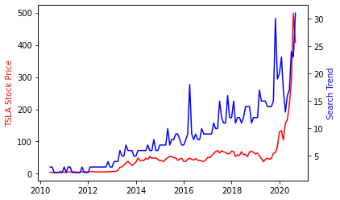

```python
ax1 = plt.gca()
ax2 = ax1.twinx()

ax1.plot(df_tesla.MONTH, df_tesla.TSLA_USD_CLOSE, 'r')
ax2.plot(df_tesla.MONTH, df_tesla.TSLA_WEB_SEARCH, 'b')

ax1.set_ylabel('TSLA Stock Price', color='r')
ax2.set_ylabel('Search Trend', color='b')
```

**Challenge**: Make the chart larger and easier to read.

1. Increase the figure size (e.g., to 14 by 8).
2. Increase the font sizes for the labels and the ticks on the x-axis to 14.
3. Rotate the text on the x-axis by 45 degrees.
4. Make the lines on the chart thicker.
5. Add a title that reads 'Tesla Web Search vs Price'
6. Keep the chart looking sharp by changing the dots-per-inch or [DPI value](https://matplotlib.org/3.1.1/api/_as_gen/matplotlib.pyplot.figure.html).
7. Set minimum and maximum values for the y and x axis. Hint: check out methods like [set_xlim()](https://matplotlib.org/3.1.1/api/_as_gen/matplotlib.axes.Axes.set_xlim.html).
8. Finally use [plt.show()](https://matplotlib.org/3.2.1/api/_as_gen/matplotlib.pyplot.show.html) to display the chart below the cell instead of relying on the automatic notebook output.

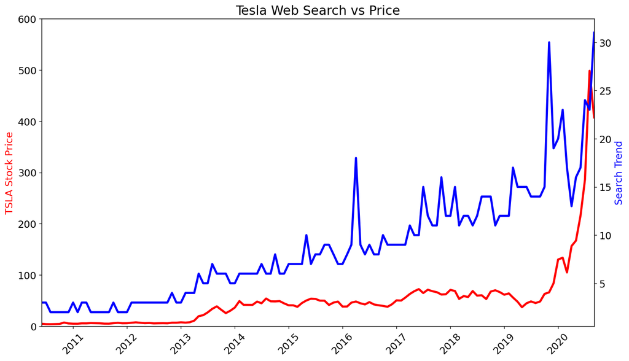

```python
# 1. Increase the figure size
# 6. Keep the chart looking sharp by changing the dots-per-inch or DPI value
plt.figure(figsize=(14,8), dpi=120)
# 3. Rotate the text on the x-axis by 45 degrees.
# 2. Increase the font sizes for the ticks on the x-axis to 14.
plt.xticks(fontsize=14, rotation=45)
# 5. Add a title that reads 'Tesla Web Search vs Price'
plt.title("Tesla Web Search vs Price", fontsize=18)
# 7. Set minimum and maximum values for x axis.
plt.xlim(df_tesla.MONTH[0], df_tesla.MONTH.iloc[-1]) # Alternatively I can use the min and max functions:
# plt.xlim([df_tesla.MONTH.min(), df_tesla.MONTH.max()])


ax1 = plt.gca()
ax2 = ax1.twinx()

ax1.plot(df_tesla.MONTH, df_tesla.TSLA_USD_CLOSE, 'r', linewidth=3) # 4. Make the lines on the chart thicker.
ax2.plot(df_tesla.MONTH, df_tesla.TSLA_WEB_SEARCH, 'b', linewidth=3)
# 7. Set minimum and maximum values for the y axis.
ax1.set_ylim(0, 600)

ax1.set_ylabel('TSLA Stock Price', color='r', fontsize=14) # 2. Increase the font sizes for the labels on the y-axis to 14.
ax2.set_ylabel('Search Trend', color='b', fontsize=14)

# 2. Increase the font sizes for the ticks on the y-axis to 14.
plt.setp(ax1.get_yticklabels(), fontsize=14)
plt.setp(ax2.get_yticklabels(), fontsize=14)

plt.show() # 8. Finally use plt.show() to display the chart below the cell instead of relying on the automatic notebook output.
```

### Notebook Formatting & Style Helpers

At this point, you might have seen this warning below from Matplotlib:

[figure not shown]

This is not an error, but an FYI to be explicit about which datetime converter to use. We have a timeline on our x-axis after all. To address this simply follow the instructions in the warning message and add the following code:

```python
# Register date converters to avoid warning messages
from pandas.plotting import register_matplotlib_converters
register_matplotlib_converters()
```

When working with time series, it's often quite difficult to get the tick marks on charts looking the way you want to. This is why we have Locator helpers.

Using Locators we can change our x-axis from looking like this:

[figure not shown]

to looking like this:

[figure not shown]

The first step is importing matplotlib.dates. This is where all the date plotting capabilities live.

Next, we need a YearLocator() and a MonthLocator() objects, which will help Matplotlib find the years and the months. Then we also need a DateFormatter(), which will help us specify how we want to display the dates.

```python
import matplotlib.dates as mdates
# Create locators for ticks on the time axis
years = mdates.YearLocator()
months = mdates.MonthLocator()
years_formatter = mdates.DateFormatter('%Y')
```

How to add tick formatting for dates on the x-axis.

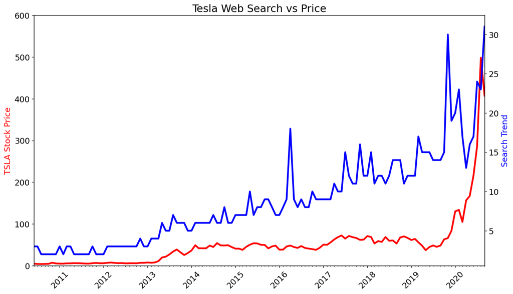

```python
plt.figure(figsize=(14,8), dpi=120)
plt.xticks(fontsize=14, rotation=45)
plt.title("Tesla Web Search vs Price", fontsize=18)
plt.xlim([df_tesla.MONTH.min(), df_tesla.MONTH.max()])

ax1 = plt.gca()
ax2 = ax1.twinx()

ax1.plot(df_tesla.MONTH, df_tesla.TSLA_USD_CLOSE, 'r', linewidth=3)
ax2.plot(df_tesla.MONTH, df_tesla.TSLA_WEB_SEARCH, 'b', linewidth=3)

ax1.set_ylim(0, 600)
ax1.set_ylabel('TSLA Stock Price', color='r', fontsize=14)
ax2.set_ylabel('Search Trend', color='b', fontsize=14)
plt.setp(ax1.get_yticklabels(), fontsize=14)
plt.setp(ax2.get_yticklabels(), fontsize=14)

# Adding tick marks to the x-axis
ax1.xaxis.set_major_locator(years)
ax1.xaxis.set_major_formatter(years_formatter)
ax1.xaxis.set_minor_locator(months)

plt.show()
```

### Bitcoin (BTC) Price v.s. Search Volume

**Challenge**: Create the same chart for the Bitcoin Prices vs. Search volumes.

1. Modify the chart title to read 'Bitcoin News Search vs Resampled Price'
2. Change the y-axis label to 'BTC Price'
3. Change the y- and x-axis limits to improve the appearance
4. Investigate the [linestyles](https://matplotlib.org/3.2.1/api/_as_gen/matplotlib.pyplot.plot.html) to make the BTC price a dashed line
5. Investigate the [marker types](https://matplotlib.org/3.2.1/api/markers_api.html) to make the search datapoints little circles
6. Were big increases in searches for Bitcoin accompanied by big increases in the price?

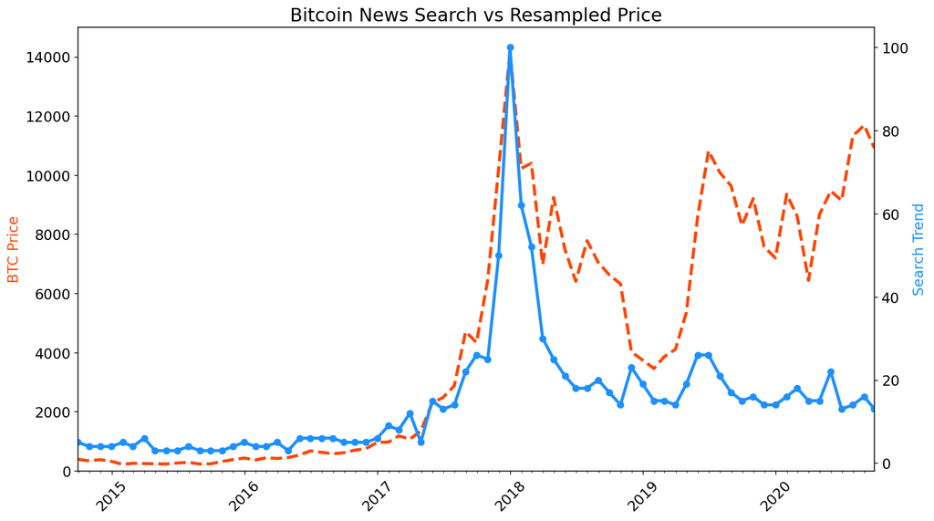

```python
plt.figure(figsize=(14,8), dpi=120)
plt.xticks(fontsize=14, rotation=45)
plt.title("Bitcoin News Search vs Resampled Price", fontsize=18) # 1. Modify the chart title to read 'Bitcoin News Search vs Resampled Price'
plt.xlim([df_btc_price_monthly.DATE.min(), df_btc_price_monthly.DATE.max()]) # 3. Change the x-axis limit to improve the appearance

ax1 = plt.gca()
ax2 = ax1.twinx()

ax1.plot(df_btc_price_monthly.DATE, df_btc_price_monthly.CLOSE, 'orangered', linewidth=3, linestyle='--') # 4. Make the BTC price a dashed line
# We use the same x data as above:
ax2.plot(df_btc_price_monthly.DATE, df_btc_search.BTC_NEWS_SEARCH, 'dodgerblue', linewidth=3, marker='o') # 5. Make the search datapoints little circles

ax1.set_ylim(0, 15000) # 3. Change the y-axis limit to improve the appearance
ax1.set_ylabel('BTC Price', color='orangered', fontsize=14) # 2. Change the y-axis label to 'BTC Price'
ax2.set_ylabel('Search Trend', color='dodgerblue', fontsize=14)
plt.setp(ax1.get_yticklabels(), fontsize=14)
plt.setp(ax2.get_yticklabels(), fontsize=14)

ax1.xaxis.set_major_locator(years)
ax1.xaxis.set_major_formatter(years_formatter)
ax1.xaxis.set_minor_locator(months)

plt.show()
```

### Unemployement Benefits Search vs. Actual Unemployment in the U.S.

**Challenge** Plot the search for "unemployment benefits" against the unemployment rate.

1. Change the title to: Monthly Search of "Unemployment Benefits" in the U.S. vs the U/E Rate
2. Change the y-axis label to: FRED U/E Rate
3. Change the axis limits
4. Add a grey [grid](https://matplotlib.org/3.2.1/api/_as_gen/matplotlib.pyplot.grid.html) to the chart to better see the years and the U/E rate values. Use dashes for the line style
5. Can you discern any seasonality in the searches? Is there a pattern?

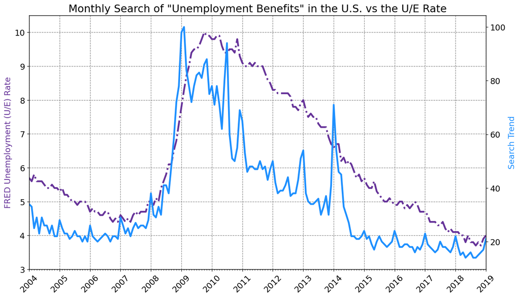

```python
plt.figure(figsize=(14,8), dpi=120)
plt.xticks(fontsize=14, rotation=45)
plt.title('Monthly Search of "Unemployment Benefits" in the U.S. vs the U/E Rate', fontsize=18) # 1. Change the title
plt.xlim([df_unemployment.MONTH.min(), df_unemployment.MONTH.max()]) # 3. Change the axis limits

ax1 = plt.gca()
ax2 = ax1.twinx()

ax1.plot(df_unemployment.MONTH, df_unemployment.UNRATE, 'rebeccapurple', linewidth=3, linestyle='-.')
ax2.plot(df_unemployment.MONTH, df_unemployment.UE_BENEFITS_WEB_SEARCH, 'dodgerblue', linewidth=3)

ax1.set_ylim(3, 10.5) # 3. Change the axis limits
ax1.set_ylabel('FRED Unemployment (U/E) Rate', color='rebeccapurple', fontsize=14) # 2. Change the y-axis label
ax2.set_ylabel('Search Trend', color='dodgerblue', fontsize=14)
plt.setp(ax1.get_yticklabels(), fontsize=14)
plt.setp(ax2.get_yticklabels(), fontsize=14)

ax1.xaxis.set_major_locator(years)
ax1.xaxis.set_major_formatter(years_formatter)
ax1.xaxis.set_minor_locator(months)

# 4. Add a grid
ax1.grid(color='grey', linestyle='--')

plt.show()
```

**Challenge**: Calculate the 3-month or 6-month rolling average for the web searches. Plot the 6-month rolling average search data against the actual unemployment. What do you see in the chart? Which line moves first?

```python
roll_df = df_unemployment.rolling(window=6).mean()
roll_df
```

|  | UE_BENEFITS_WEB_SEARCH | UNRATE |
| --- | --- | --- |
| 0 | NaN | NaN |
| 1 | NaN | NaN |
| 2 | NaN | NaN |
| 3 | NaN | NaN |
| 4 | NaN | NaN |
| ... | ... | ... |
| 176 | 14.833333 | 3.850000 |
| 177 | 14.666667 | 3.816667 |
| 178 | 15.000000 | 3.800000 |
| 179 | 15.333333 | 3.783333 |
| 180 | 16.166667 | 3.816667 |

181 rows × 2 columns

Use this code if we want to specify exactly which columns to do the roll on:

```
roll_df = df_unemployment[['UE_BENEFITS_WEB_SEARCH', 'UNRATE']].rolling(window=6).mean()
```

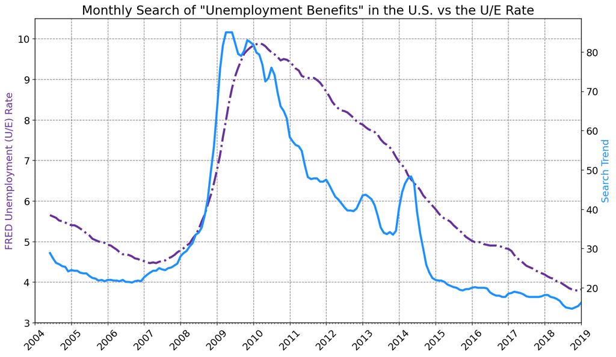

```python
plt.figure(figsize=(14,8), dpi=120)
plt.xticks(fontsize=14, rotation=45)
plt.title('Monthly Search of "Unemployment Benefits" in the U.S. vs the U/E Rate', fontsize=18)
plt.xlim([df_unemployment.MONTH.min(), df_unemployment.MONTH.max()])

ax1 = plt.gca()
ax2 = ax1.twinx()

ax1.plot(df_unemployment.MONTH, roll_df.UNRATE, 'rebeccapurple', linewidth=3, linestyle='-.') # Rolling mean 6 months for the Web Search y-data
ax2.plot(df_unemployment.MONTH, roll_df.UE_BENEFITS_WEB_SEARCH, 'dodgerblue', linewidth=3) # Rolling mean 6 months for the Web Search y-data

ax1.set_ylim(3, 10.5)
ax1.set_ylabel('FRED Unemployment (U/E) Rate', color='rebeccapurple', fontsize=14)
ax2.set_ylabel('Search Trend', color='dodgerblue', fontsize=14)
plt.setp(ax1.get_yticklabels(), fontsize=14)
plt.setp(ax2.get_yticklabels(), fontsize=14)

ax1.xaxis.set_major_locator(years)
ax1.xaxis.set_major_formatter(years_formatter)
ax1.xaxis.set_minor_locator(months)

ax1.grid(color='grey', linestyle='--')

plt.show()
```

What is this telling us? We see that searches for "Unemployment Benefits" happen before the actual official unemployment rate goes up. Similarly, the search popularity for the term goes down before the unemployment rate decreases. In other words, these searches seem to act as a **leading economic indicator** for the unemployment rate (which is a **lagging indicator**).

### Including 2020 in Unemployment Charts

**Challenge**: Read the data in the 'UE Benefits Search vs UE Rate 2004-20.csv' into a DataFrame. Convert the MONTH column to Pandas Datetime objects and then plot the chart. What do you see?

```python
df_ue_2020 = pd.read_csv('UE Benefits Search vs UE Rate 2004-20.csv')
df_ue_2020.MONTH = pd.to_datetime(df_ue_2020.MONTH)
```

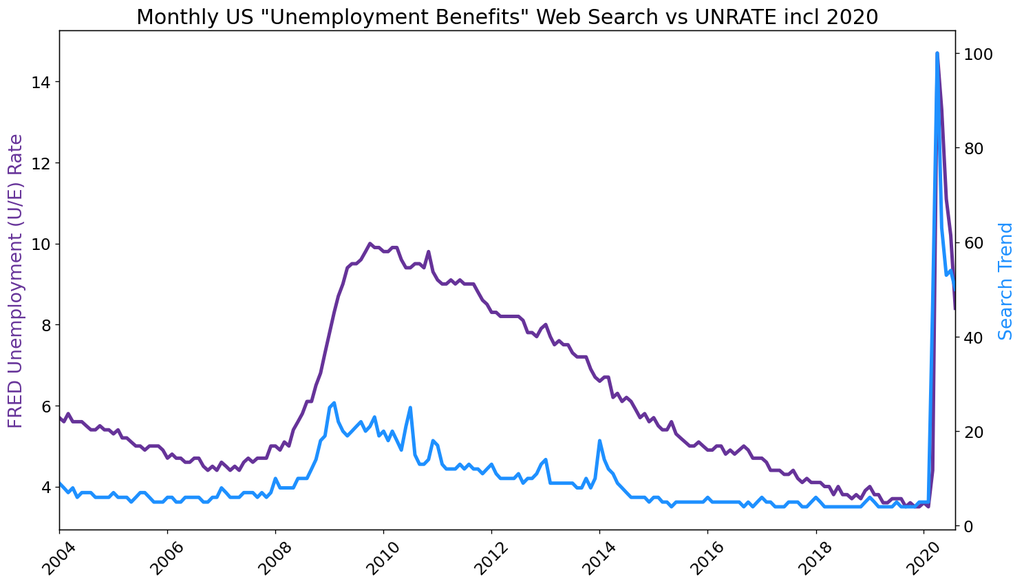

```python
plt.figure(figsize=(14,8), dpi=120)
plt.xticks(fontsize=14, rotation=45)
plt.title('Monthly US "Unemployment Benefits" Web Search vs UNRATE incl 2020', fontsize=18)
plt.xlim([df_ue_2020.MONTH.min(), df_ue_2020.MONTH.max()])

ax1 = plt.gca()
ax2 = ax1.twinx()

ax1.plot(df_ue_2020.MONTH, df_ue_2020.UNRATE, 'rebeccapurple', linewidth=3) # Rolling mean 6 months for the Web Search y-data
ax2.plot(df_ue_2020.MONTH, df_ue_2020.UE_BENEFITS_WEB_SEARCH, 'dodgerblue', linewidth=3) # Rolling mean 6 months for the Web Search y-data

# ax1.set_ylim(3, 10.5)
ax1.set_ylabel('FRED Unemployment (U/E) Rate', color='rebeccapurple', fontsize=16)
ax2.set_ylabel('Search Trend', color='dodgerblue', fontsize=16)
plt.setp(ax1.get_yticklabels(), fontsize=14)
plt.setp(ax2.get_yticklabels(), fontsize=14)

# ax1.xaxis.set_major_locator(years)
# ax1.xaxis.set_major_formatter(years_formatter)
# ax1.xaxis.set_minor_locator(months)

# ax1.grid(color='grey', linestyle='--')

plt.show()
```

What we see is not pretty. The US unemployment rate spiked to unprecedented levels during the COVID pandemic, dwarfing the levels seen during the financial crisis. Let's hope the recovery will be swifter this time.

# Learning Points & Summary

In this lesson we looked at how to:

- How to use `.describe()` to quickly see some descriptive statistics at a glance.
- How to use `.resample()` to make a time-series data comparable to another by changing the periodicity, and chain it with `.mean()`, `.first()` or `.last()`
- How to use "rule" parameter in `.resample()` (e.g. 'M' or 'MS'), and the `group_keys=False` to avoid duplicating the index. Or else, using `reset_index(drop=True, inplace=True)` to reset the index
- How to work with `matplotlib.dates` Locators to better style a timeline (e.g., an axis on a chart).
- How to use `.isna().any().any()` or `.isna().values`
- The fact that `True + True -> 2` so we can sum booleans to find the number of NaN values with `.isna().values.sum()`
- How to change the resolution of a chart using the figure's `dpi`
- How to create dashed `'--'` and dotted `'-.'` lines using `linestyles`
- How to use different kinds of markers (e.g., `'o'` or `'^'`) on charts.
- Fine-tuning the styling of Matplotlib charts by using limits, labels, `linewidth` and colours (both in the form of named colours and HEX codes).
- Using `.grid()` to help visually identify seasonality in a time series.
- Review of using Logical Operators (`|` `&` `~`), `.dropna()`, converting to Datetime `pd.to_datetime()`, and `DataFrame.rolling(window=6).mean()`
- Converting a Datetime Series into a formatted String Series: `Series.dt.strftime("%Y-%m")`
- Each Dataframe has a Styler object attribute, from which we can derive to display the df the way we want. Examples:

  ```
  df_btc_search_styler = df_btc_search.style.format({'MONTH': lambda t: t.strftime("%Y-%m")})
  df_btc_search_styler.hide_index(pd.IndexSlice[4:])
  ```

- Finding the current Pandas version with `pd.__version__`